# VeRUS: Verification of Reference Intervals Based on the Uncertainty of Sampling

Matthias Beck & Christopher M Rank

2025-11-05

## Introduction

So far, most methods for the verification of reference intervals require the collection of reference samples that reasonably represent the local population. This is often not feasible due to the high costs and the time-consuming process of collecting these samples. The method **VeRUS** (Verification of Reference Intervals Based on the Uncertainty of Sampling) is a novel approach to verify reference intervals without the collection of samples. Instead, **VeRUS** combines the already available data from the laboratory information system with the uncertainty of sampling to verify the reference intervals. A detailed description of the method can be found in [https://doi.org/10.1515/cclm-2025-0728].

## Description of VeRUS

At the core of VeRUS is the construction of uncertainty margins around the limits of the reference intervals. The uncertainty margins are defined as the approximated confidence interval of population quantiles at a given sample size. As the uncertainty margins are independent of the sample size of the reference sample, they enable direct comparison of reference intervals derived from different sample sizes. These uncertainty margins can be shown when printing the result of *findRI*. For demonstration purposes, *testcase 1* is used as an example for RWD: The *print* and *plot* functions can now be used to display the uncertainty margins.

```r
library(refineR)
fit <- findRI(Data = testcase1)
print(fit, uncertaintyRegion = "uncertaintyMargin")
```

```
##
## Estimated Reference Interval
## ------------------------------------------------
## lower limit [ 2.5%]: 10.3 (8.31; 12.3)
## upper limit [97.5%]: 29.9 (27.9; 31.9)
##
## Width of the uncertainty margin [n = 120]: 90%
##
## Model Parameters
## ------------------------------------------------
##      method: refineR (v2.0.0)
##       model: BoxCox
##      N data: 10000
##     rounded: no
##   point est: fullDataEst
## uncertainty: uncertaintyMargin
##      lambda: 1
##          mu: 19.1
##       sigma: 4.99
##       shift: 0
##        cost: -25.6
## NP fraction: 0.803
```

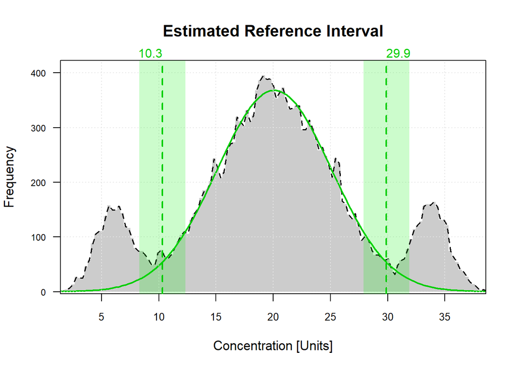

```r
# The uncertainty margins are shown in the plot
plot(fit, uncertaintyRegion = "uncertaintyMargin")
```

## Application of VeRUS

The standard use case of **VeRUS** requires only the result of refineR’s *findRI* function and the candidate reference interval ,i.e., the one that is supposed to be verified. Suppose laboratory A wants to verify the reference interval [9.1, 31.5] for a certain biomarker. The verification can be done as follows:

1. Ensuring comparable analytical methods and demographics:
   - Analytical methods: The analytical methods used in laboratory A should be comparable to those used to establish the reference interval.
   - Demographics: The local population of laboratory A should be similar to the population from which the reference interval was derived.
2. Careful filtering of the RWD according to Ammer et al. 2023 [https://doi.org/10.1093/jalm/jfac101].
3. Application of the *findRI* function to model the reference distribution from the filtered RWD.
4. Using the *verifyRI* function to verify the reference interval.

The most relevant parameters of the *verifyRI* function are:

- *RIdata*: (*RWDRI*) object (result of the *findRI* function) or a (*numeric*) vector specifying a reference interval.
- *RIcand*: (*RWDRI*) object or a (*numeric*) vector specifying the reference interval that needs to be verified.
- *RIperc*: (*numeric*) vector specifying the percentiles which define the reference interval (default: c(0.025, 0.975)).
- *printResults*: (*logical*) indicating whether to print results to the console.
- *generatePlot*: (*logical*) indicating whether to generate a verification plot.

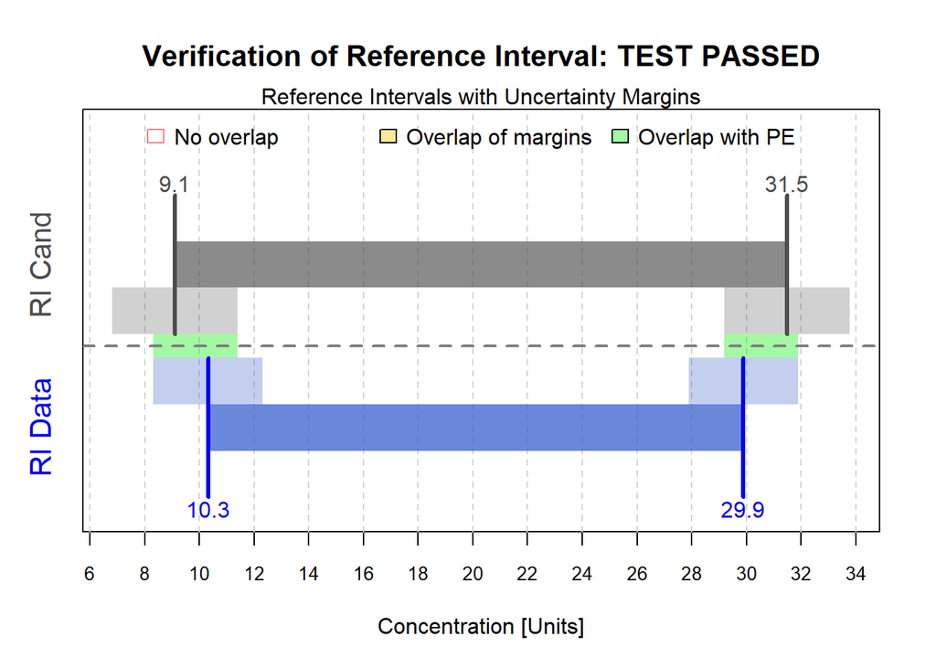

```
##
##  Verification of Reference Interval [VeRUS]
## ------------------------------------------
##
## Verification result: TEST PASSED (all point estimates within uncertainty margins)
##
## Perc  | RI Data           | RI Cand           | Overlap
## ----- | ----------------- | ----------------- | ---------------
##  2.5% | 10.3 (8.31; 12.3) |  9.1 (6.81; 11.4) | Overlap with PE
## 97.5% | 29.9 (27.9; 31.9) | 31.5 (29.2; 33.8) | Overlap with PE
##
##
## Fraction of data within/outside of reference interval:
## Interval | Reference Limits | Below | Within | Above
## -------- | ---------------- | ----- | ------ | -----
##  RI Data |    [10.3 , 29.9] | 12.2% |  76.0% | 11.8%
##  RI Cand |    [ 9.1 , 31.5] | 10.9% |  78.7% | 10.4%
```

```r
# Suppose the currently used reference interval is [9.1, 31.5]
verifyRI(RIdata = fit, RIcand = c(9.1, 31.5))
```

As can be seen, the reference interval [9.1, 31.5] is verified by the method **VeRUS**. The first table that is printed shows the uncertainty margins around the point estimates of each reference limit. The second table that is printed shows the fraction of samples within the Data argument of `findRI` that are outside (below or above) or within the respective reference interval.

The *verifyRI* function is flexible. If only the 99th percentile is relevant, one could verify it as follows:

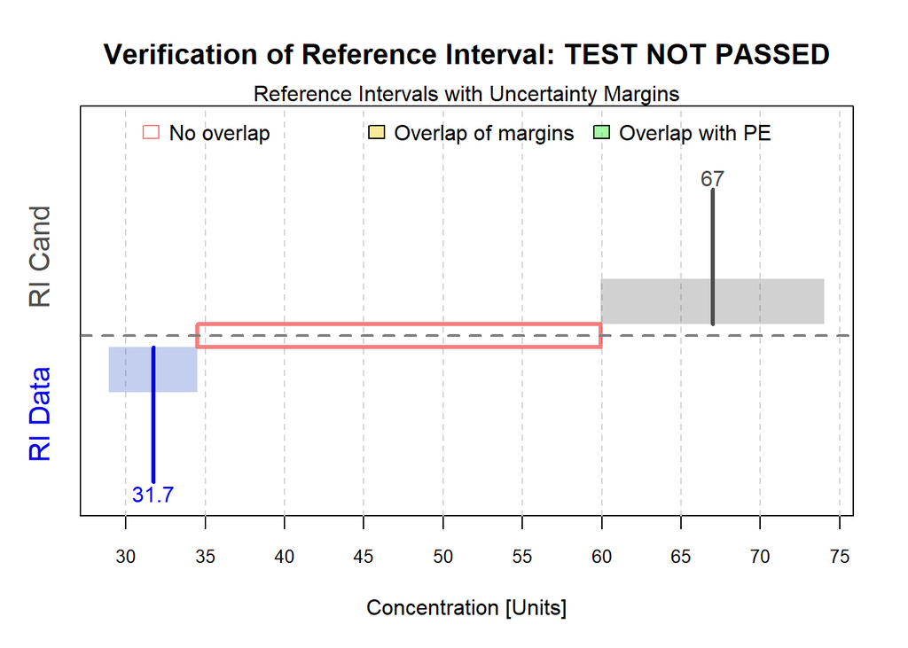

```
##
##  Verification of Reference Interval [VeRUS]
## ------------------------------------------
##
## Verification result: TEST NOT PASSED
##
## Perc  | RI Data           | RI Cand        | Overlap
## ----- | ----------------- | -------------- | ----------
## 99.0% | 31.7 (28.9; 34.5) |  67 ( 60;  74) | No overlap
##
##
## Fraction of data within/outside of reference interval:
## Interval | Reference Limits | Within | Above
## -------- | ---------------- | ------ | ------
##  RI Data |      [   , 31.7] |  89.8% |  10.2%
##  RI Cand |      [   ,   67] | 100.0% |   0.0%
```

```r
verifyRI(RIdata = fit, RIcand = 67, RIperc = 0.99)
```

However, if more than one reference limit of a numeric *RIcand* is available, it is recommended to provide at least two of them as a vector (e.g., c(lower, upper)) and their corresponding percentiles as *RIperc*. Providing only a single value - if *RIdata* is an RWDRI object and *RICand* is a numeric vector - necessitates an imputation step which may lead to unexpected results.

### Possible Inputs of the *verifyRI* Function

The *verifyRI* function can be used to compare:

- a RWDRI object (result of the *findRI* function) with a numeric reference interval
- two numeric reference intervals
- two RWDRI objects

If the parameters describing the reference distribution from which the candidate RI is derived are known, a custom RWDRI object can be defined and provided to the *verifyRI* function to improve the accuracy of the verification.

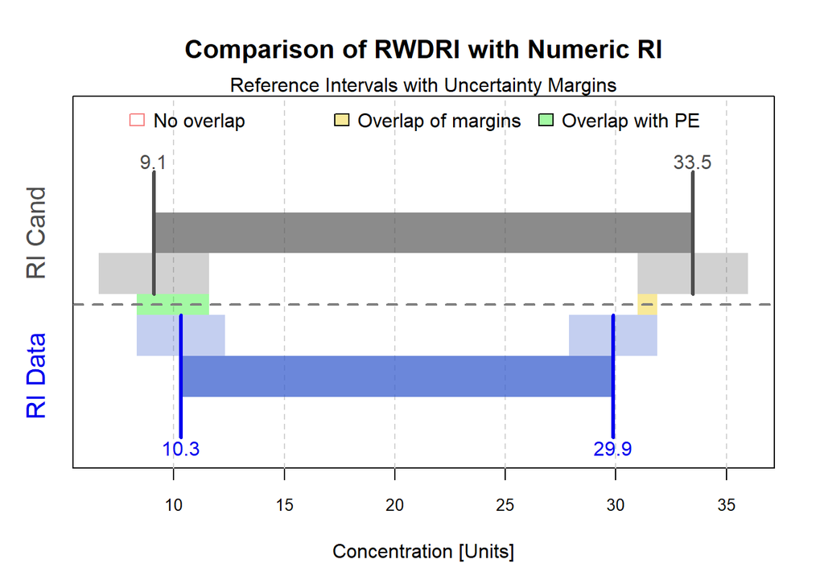

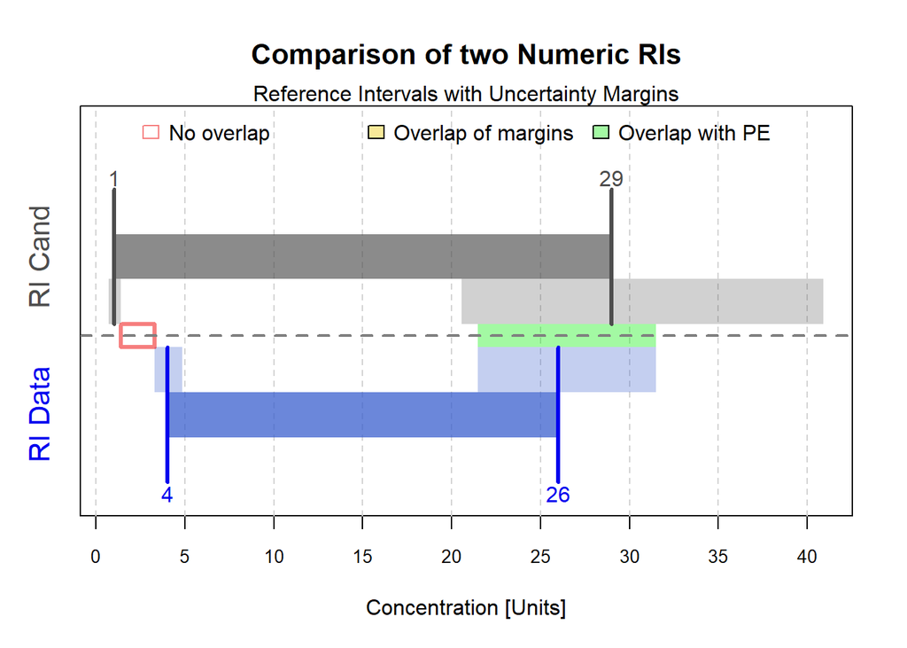

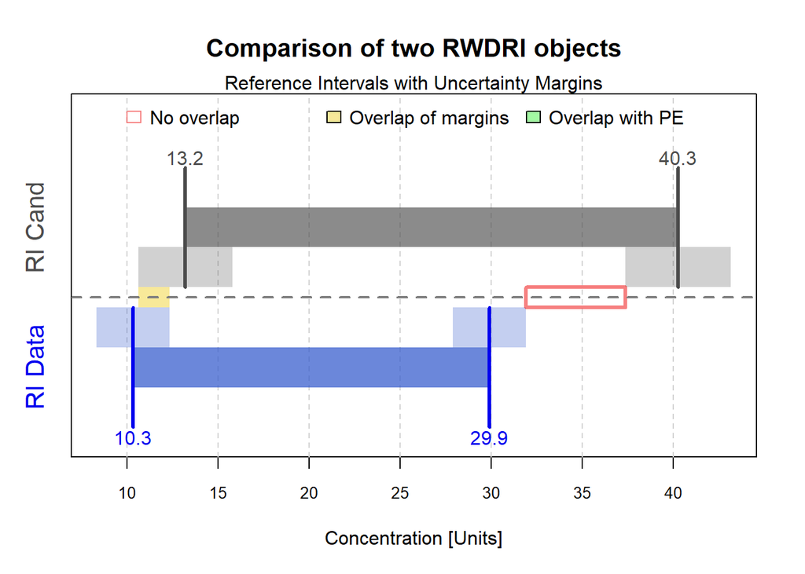

```r
# compare RWDRI object with a numeric reference interval
verifyRI(RIdata = fit, RIcand = c(9.1, 33.5),
 title = "Comparison of RWDRI with Numeric RI",
 printResults = FALSE)
# compare two numeric RIs
verifyRI(RIdata = c(4, 26), RIcand = c(1, 29),
 title = "Comparison of two Numeric RIs",
 printResults = FALSE)

# compare two RWDRI objects
# custom RWDRI object describing the reference distribution
# Mu and Sigma define the mean and standard deviation of a normal distribution.
# Then the inverse Box-Cox transformation is applied to the data with the power parameter Lambda.
# The Shift parameter is used to shift the distribution to the desired location.
custom_RWDRI <- list(Mu = 20, Sigma = 5, Lambda = 0.9, Shift = 0)
class(custom_RWDRI) <- "RWDRI"
verifyRI(RIdata = fit, RIcand = custom_RWDRI,
 title = "Comparison of two RWDRI objects",
 printResults = FALSE)
```